# 淘宝用户行为分析

2014年是阿里巴巴集团移动电子商务业务快速发展的一年。例如，2014年11月11日的移动销售中的移动终端商品总销售额（GMV）占总GMV的42.6％。与PC时代相比，移动终端可以随时随地访问网络。此外，他们还拥有更丰富的背景数据，例如用户的位置信息，访问时间的规律性等。该数据基于阿里巴巴M-Commerce平台上的真实用户商品行为数据。同时，它提供了移动时代典型的位置信息。

## 项目描述

用户研究是产品设计的第一步，其中以大量数据为支撑的用户行为分析尤为重要，这个项目我们采用淘宝“百万级”用户数据，深度分析用户行为，主要包含基本用户购物情况数据统计，复购率分析，获客分析，留存分析，从时间维度分析每天用户行为，各环节转换率分析，指导运营人员及时调整运营策略。

## 项目步骤

### 主要完成目标如下：

1. 读取数据，数据抽样
2. 数据的描述性分析
3. 数据的一致性处理  
   (1)修改数据字段类型  
   (2)删除不需要的列数据：地理位置
4. 探索性分析：统计浏览量，独立访客数，分析有购买行为的用户数，复购率分析  
   (1)统计pv：Page View, 即页面浏览量或点击量  
   (2)UV（用户总数）：9924 UV(独立访客)：即Unique Visitor,访问网站的一台电脑客户端为一个访客。00:00-24:00内相同的客户端只被计算一次  
   (3)分析有购买行为的用户数  
   (4)分析复购率
5. 探索性分析：分析活跃度，从时间维度分析用户行为  
   (1)每周的用户行为数量变化趋势  
   (2)每天PV变化趋势分析  
   (3)分析一天中的不同时段用户的行为
6. 获客分析
7. 转化率分析
8. 留存率分析

```python
import warnings
warnings.filterwarnings("ignore")
import matplotlib.pyplot as plt
plt.rcParams['axes.unicode_minus'] = False
plt.rcParams['font.sans-serif']=['SimHei']  #显示中文标签
import numpy as np
import seaborn as sns
```

### 读取数据，这里是完整的12256906条数据

数据集来源：https://tianchi.aliyun.com/dataset/dataDetail?dataId=46

```python
# import pandas as pd
# data=pd.read_csv('tianchi_mobile_recommend_train_user.csv')
# data.head()
# data.info()
```

### 数据量过大，所以这里随机抽取了100万条数据，并且存储为user.csv

```python
#随机、可放回抽样
# data=data.sample(n=1000000,replace=True,axis=0)
# data.to_csv("user.csv")
```

```python
# 存储的user.csv文件
import matplotlib.pyplot as plt
import pandas as pd
plt.rcParams['axes.unicode_minus'] = False
plt.rcParams['font.sans-serif']=['SimHei']  #显示中文标签
data=pd.read_csv('user.csv')
```

```python
data.head()
```

|  | user_id | item_id | behavior_type | user_geohash | item_category | time |
| --- | --- | --- | --- | --- | --- | --- |
| 0 | 30282407 | 189836232 | 1 | NaN | 6431 | 2014-12-15 14 |
| 1 | 91557809 | 43134506 | 1 | NaN | 1863 | 2014-12-10 18 |
| 2 | 21233965 | 3776579 | 3 | 94rlqle | 13664 | 2014-12-02 20 |
| 3 | 54590569 | 107237828 | 1 | NaN | 1863 | 2014-12-02 03 |
| 4 | 137120980 | 54431185 | 1 | 94jrwhn | 5395 | 2014-12-09 17 |

```python
data.shape
```

```
(1000000, 6)
```

1. user_id：用户id
2. item_id：商品id
3. behavior_type:用户行为
4. user_geohash：地理位置-加密处理
5. item_category：品类id
6. time：用户行为发生的时间

```python
data.info()
```

```
<class 'pandas.core.frame.DataFrame'>
RangeIndex: 1000000 entries, 0 to 999999
Data columns (total 6 columns):
 #   Column         Non-Null Count    Dtype
---  ------         --------------    -----
 0   user_id        1000000 non-null  int64
 1   item_id        1000000 non-null  int64
 2   behavior_type  1000000 non-null  int64
 3   user_geohash   320202 non-null   object
 4   item_category  1000000 non-null  int64
 5   time           1000000 non-null  object
dtypes: int64(4), object(2)
memory usage: 45.8+ MB
```

```python
# 删除地理位置这一列数据
data.drop(labels='user_geohash',
         axis=1,inplace=True)
```

```python
data.columns
```

```
Index(['user_id', 'item_id', 'behavior_type', 'item_category', 'time'], dtype='object')
```

```python
# 拆分time这一列数据
data['date']=data['time'].apply(lambda s:s.split()[0])
data['hour']=data['time'].apply(lambda s:s.split()[1])
data.head()
```

|  | user_id | item_id | behavior_type | item_category | time | date | hour |
| --- | --- | --- | --- | --- | --- | --- | --- |
| 0 | 30282407 | 189836232 | 1 | 6431 | 2014-12-15 14 | 2014-12-15 | 14 |
| 1 | 91557809 | 43134506 | 1 | 1863 | 2014-12-10 18 | 2014-12-10 | 18 |
| 2 | 21233965 | 3776579 | 3 | 13664 | 2014-12-02 20 | 2014-12-02 | 20 |
| 3 | 54590569 | 107237828 | 1 | 1863 | 2014-12-02 03 | 2014-12-02 | 03 |
| 4 | 137120980 | 54431185 | 1 | 5395 | 2014-12-09 17 | 2014-12-09 | 17 |

```python
data.info()
```

```
<class 'pandas.core.frame.DataFrame'>
RangeIndex: 1000000 entries, 0 to 999999
Data columns (total 7 columns):
 #   Column         Non-Null Count    Dtype
---  ------         --------------    -----
 0   user_id        1000000 non-null  int64
 1   item_id        1000000 non-null  int64
 2   behavior_type  1000000 non-null  int64
 3   item_category  1000000 non-null  int64
 4   time           1000000 non-null  object
 5   date           1000000 non-null  object
 6   hour           1000000 non-null  object
dtypes: int64(4), object(3)
memory usage: 53.4+ MB
```

```python
# 修改日期类型
data['time']=pd.to_datetime(data['time'])
data['date']=pd.to_datetime(data['date'])
data['hour']=data['hour'].astype('int32')
```

```python
data.info()
```

```
<class 'pandas.core.frame.DataFrame'>
RangeIndex: 1000000 entries, 0 to 999999
Data columns (total 7 columns):
 #   Column         Non-Null Count    Dtype
---  ------         --------------    -----
 0   user_id        1000000 non-null  int64
 1   item_id        1000000 non-null  int64
 2   behavior_type  1000000 non-null  int64
 3   item_category  1000000 non-null  int64
 4   time           1000000 non-null  datetime64[ns]
 5   date           1000000 non-null  datetime64[ns]
 6   hour           1000000 non-null  int32
dtypes: datetime64[ns](2), int32(1), int64(4)
memory usage: 49.6 MB
```

```python
data.head()
```

|  | user_id | item_id | behavior_type | item_category | time | date | hour |
| --- | --- | --- | --- | --- | --- | --- | --- |
| 0 | 30282407 | 189836232 | 1 | 6431 | 2014-12-15 14:00:00 | 2014-12-15 | 14 |
| 1 | 91557809 | 43134506 | 1 | 1863 | 2014-12-10 18:00:00 | 2014-12-10 | 18 |
| 2 | 21233965 | 3776579 | 3 | 13664 | 2014-12-02 20:00:00 | 2014-12-02 | 20 |
| 3 | 54590569 | 107237828 | 1 | 1863 | 2014-12-02 03:00:00 | 2014-12-02 | 3 |
| 4 | 137120980 | 54431185 | 1 | 5395 | 2014-12-09 17:00:00 | 2014-12-09 | 17 |

```python
data['behavior_type'].unique()
```

```
array([1, 3, 4, 2])
```

```python
# 1234  浏览 加购物车 收藏 购买
behavior_map={1:'pv',2:'cart',3:'collect',4:'buy'}
data['behavior_type']=data['behavior_type'].map(behavior_map)
data.head()
```

|  | user_id | item_id | behavior_type | item_category | time | date | hour |
| --- | --- | --- | --- | --- | --- | --- | --- |
| 0 | 30282407 | 189836232 | pv | 6431 | 2014-12-15 14:00:00 | 2014-12-15 | 14 |
| 1 | 91557809 | 43134506 | pv | 1863 | 2014-12-10 18:00:00 | 2014-12-10 | 18 |
| 2 | 21233965 | 3776579 | collect | 13664 | 2014-12-02 20:00:00 | 2014-12-02 | 20 |
| 3 | 54590569 | 107237828 | pv | 1863 | 2014-12-02 03:00:00 | 2014-12-02 | 3 |
| 4 | 137120980 | 54431185 | pv | 5395 | 2014-12-09 17:00:00 | 2014-12-09 | 17 |

```python
# 统计pv  100w
data['behavior_type'].value_counts()
```

```
behavior_type
pv         942150
collect     28242
cart        19837
buy          9771
Name: count, dtype: int64
```

```python
# 统计uv 独立访客 100w  有多少个实际用户 9924
data.groupby('user_id')['behavior_type'].count()
```

```
user_id
4913         141
6118           9
7528          17
7591          75
12645         27
            ...
142376113     18
142412247     19
142430177    110
142450275    569
142455899    106
Name: behavior_type, Length: 9924, dtype: int64
```

```python
# 计算非重复的用户数量
data['user_id'].nunique()
```

```
9924
```

```python
# (3)分析有购买行为的用户数
data_buy=data[data['behavior_type']=='buy']
data_buy['user_id'].nunique()
```

```
4522
```

```python
# (4)分析复购率
# 有复购行为的用户数/有购买行为的用户数

# 复购：一天内多次购买不算复购 算一次
#       按天计算复购情况
# 计算复购率
data_rebuy=data_buy.groupby('user_id')['date'].nunique()
data_rebuy[data_rebuy>=2].count()/4522
```

```
np.float64(0.421937195931004)
```

```python
data_rebuy
```

```
user_id
4913         1
7528         1
7591         1
79824        1
88930        3
            ..
142216376    1
142244794    1
142306361    1
142450275    2
142455899    2
Name: date, Length: 4522, dtype: int64
```

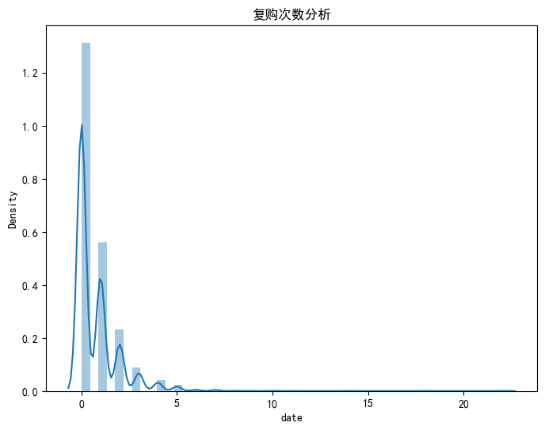

```python
# 分析有购买行为的用户 复购次数分析
plt.figure(figsize=(8,6),dpi=100)
# 密度曲线图和直方图
sns.distplot(data_rebuy-1)
plt.title('复购次数分析')
plt.show()
```

```python
# 5. 探索性分析：分析活跃度，从时间维度分析用户行为<br>
#    (1)每周的用户行为数量变化趋势<br>
#    (2)每天PV变化趋势分析<br>
#    (3)分析一天中的不同时段用户的行为<br>
```

```python
# 每周的用户行为数量变化趋势
data.head()
```

|  | user_id | item_id | behavior_type | item_category | time | date | hour |
| --- | --- | --- | --- | --- | --- | --- | --- |
| 0 | 30282407 | 189836232 | pv | 6431 | 2014-12-15 14:00:00 | 2014-12-15 | 14 |
| 1 | 91557809 | 43134506 | pv | 1863 | 2014-12-10 18:00:00 | 2014-12-10 | 18 |
| 2 | 21233965 | 3776579 | collect | 13664 | 2014-12-02 20:00:00 | 2014-12-02 | 20 |
| 3 | 54590569 | 107237828 | pv | 1863 | 2014-12-02 03:00:00 | 2014-12-02 | 3 |
| 4 | 137120980 | 54431185 | pv | 5395 | 2014-12-09 17:00:00 | 2014-12-09 | 17 |

```python
data['date'].min()
```

```
Timestamp('2014-11-18 00:00:00')
```

```python
data['date'].max()
```

```
Timestamp('2014-12-18 00:00:00')
```

```python
# data['date'].dt.year
# data['date'].dt.month
# data['date'].dt.day
# data['date'].dt.weekday
```

### 1.新建一列 星期

### 2.每周的用户行为数量变化趋势 可视化

### 3.每天PV变化趋势分析 可视化

### 4.分析一天中的不同时段用户的行为 可视化 折线图

```python
data['week']=data['date'].dt.weekday
data.head()
```

|  | user_id | item_id | behavior_type | item_category | time | date | hour | week |
| --- | --- | --- | --- | --- | --- | --- | --- | --- |
| 0 | 30282407 | 189836232 | pv | 6431 | 2014-12-15 14:00:00 | 2014-12-15 | 14 | 0 |
| 1 | 91557809 | 43134506 | pv | 1863 | 2014-12-10 18:00:00 | 2014-12-10 | 18 | 2 |
| 2 | 21233965 | 3776579 | collect | 13664 | 2014-12-02 20:00:00 | 2014-12-02 | 20 | 1 |
| 3 | 54590569 | 107237828 | pv | 1863 | 2014-12-02 03:00:00 | 2014-12-02 | 3 | 1 |
| 4 | 137120980 | 54431185 | pv | 5395 | 2014-12-09 17:00:00 | 2014-12-09 | 17 | 1 |

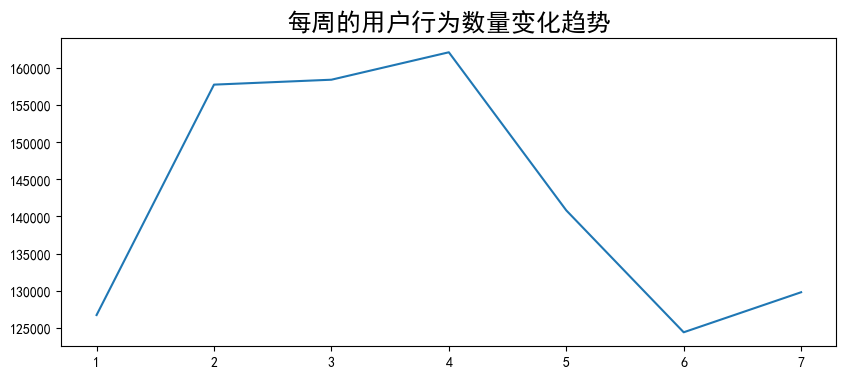

```python
# 每周的用户行为数量变化趋势
df_week=data.groupby('week')['behavior_type'].count()
df_week.index=[1,2,3,4,5,6,7]
df_week
# 可视化
plt.figure(figsize=(10,4),dpi=100)
df_week.plot()
plt.title('每周的用户行为数量变化趋势',
         fontsize=18)
plt.show()
```

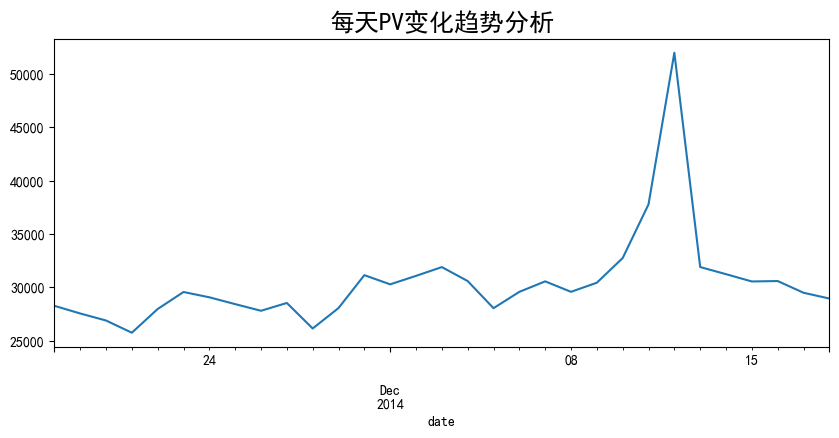

```python
# 每天PV变化趋势分析 可视化
data_pv=data[data['behavior_type']=='pv']
data_pv1=data_pv.groupby('date')['behavior_type'].count()
data_pv1
# 可视化
plt.figure(figsize=(10,4),dpi=100)
data_pv1.plot()
plt.title('每天PV变化趋势分析',
         fontsize=18)
plt.show()
```

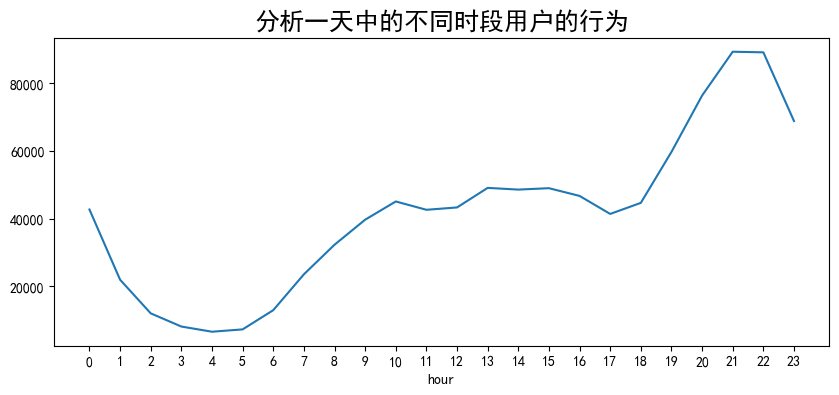

```python
# 分析一天中的不同时段用户的行为
data_hour=data.groupby('hour')['behavior_type'].count()
data_hour
# 可视化
plt.figure(figsize=(10,4),dpi=100)
data_hour.plot()
plt.title('分析一天中的不同时段用户的行为',
         fontsize=18)
plt.xticks(np.arange(0,24))
plt.show()
```

```python
# 6. 获客分析<br>
# 7. 转化率分析<br>
# 8. 留存率分析<br>
```

```python
data[data['behavior_type']=='pv']
# 转化率分析
data['behavior_type'].value_counts()
```

```
behavior_type
pv         942150
collect     28242
cart        19837
buy          9771
Name: count, dtype: int64
```

```python
9771/942150
```

```
0.010370960038210477
```

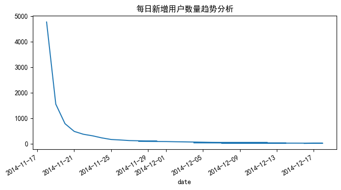

```python
#  6. 获客分析<br>
# 每一天新增多少用户 可视化
# 每一个用户 第一次访问的日期
new_vistor=data.groupby('user_id')['date'].min()
new_vistor

# 小李 11.18
# 小王 11.20
# 小杨 11.18

# 11.18 新增用户？ 2个
new_vistor1=new_vistor.value_counts()
new_vistor1

plt.figure(figsize=(8,4),dpi=100)
new_vistor1.plot()
plt.title('每日新增用户数量趋势分析')
plt.show()
```

```python
data['date']==data['date'].min()
```

```
0         False
1         False
2         False
3         False
4         False
          ...
999995    False
999996    False
999997    False
999998    False
999999    False
Name: date, Length: 1000000, dtype: bool
```

```python
#  8. 留存率分析<br>
# 日期最小的那一天为开始  计算次日留存率 7日留存率 30日留存率
# 第一天  1000人
# 次日 500 50%
# 七日 50 5%
# 第一天 用户有多少次行为的数据
first_user=data[data['date']==data['date'].min()]
first_data=first_user.groupby('user_id')['behavior_type'].count().reset_index()
first_data
```

|  | user_id | behavior_type |
| --- | --- | --- |
| 0 | 4913 | 3 |
| 1 | 12645 | 4 |
| 2 | 54056 | 1 |
| 3 | 79824 | 4 |
| 4 | 88930 | 5 |
| ... | ... | ... |
| 4763 | 142265405 | 8 |
| 4764 | 142306250 | 5 |
| 4765 | 142306361 | 2 |
| 4766 | 142368840 | 2 |
| 4767 | 142450275 | 1 |

4768 rows × 2 columns

```python
first_data.info()
```

```
<class 'pandas.core.frame.DataFrame'>
RangeIndex: 4768 entries, 0 to 4767
Data columns (total 2 columns):
 #   Column         Non-Null Count  Dtype
---  ------         --------------  -----
 0   user_id        4768 non-null   int64
 1   behavior_type  4768 non-null   int64
dtypes: int64(2)
memory usage: 74.6 KB
```

```python
data['date'].min()+np.timedelta64(1,'D')
```

```
Timestamp('2014-11-19 00:00:00')
```

```python
# 第二天 哪些用户  行为数据
second_user=data[data['date']==data['date'].min()+np.timedelta64(1,'D')]
second_data=second_user.groupby('user_id')['behavior_type'].count().reset_index()
second_data
```

|  | user_id | behavior_type |
| --- | --- | --- |
| 0 | 4913 | 2 |
| 1 | 45368 | 3 |
| 2 | 100539 | 3 |
| 3 | 104155 | 5 |
| 4 | 113251 | 6 |
| ... | ... | ... |
| 4833 | 142306250 | 2 |
| 4834 | 142337230 | 1 |
| 4835 | 142412247 | 1 |
| 4836 | 142450275 | 17 |
| 4837 | 142455899 | 1 |

4838 rows × 2 columns

```python
# 合并数据
data_date=pd.merge(first_data,second_data,on='user_id',
        how='left')
data_date.dropna(axis=0,inplace=True)
```

```python
data_date
```

|  | user_id | behavior_type_x | behavior_type_y |
| --- | --- | --- | --- |
| 0 | 4913 | 3 | 2.0 |
| 5 | 113251 | 4 | 6.0 |
| 6 | 113960 | 3 | 12.0 |
| 7 | 157097 | 2 | 1.0 |
| 8 | 189833 | 1 | 1.0 |
| ... | ... | ... | ... |
| 4759 | 142151675 | 7 | 3.0 |
| 4760 | 142181816 | 28 | 6.0 |
| 4762 | 142244794 | 10 | 8.0 |
| 4764 | 142306250 | 5 | 2.0 |
| 4767 | 142450275 | 1 | 17.0 |

3288 rows × 3 columns

```python
3288/4768
```

```
0.6895973154362416
```

```python
# 七日留存率
seven_user=data[data['date']==data['date'].min()+np.timedelta64(6,'D')]
seven_data=seven_user.groupby('user_id')['behavior_type'].count().reset_index()
seven_data
data_7date=pd.merge(first_data,seven_data,on='user_id',
        how='left')
data_7date.dropna(axis=0,inplace=True)
```

```python
data_7date
```

|  | user_id | behavior_type_x | behavior_type_y |
| --- | --- | --- | --- |
| 0 | 4913 | 3 | 3.0 |
| 1 | 12645 | 4 | 1.0 |
| 4 | 88930 | 5 | 7.0 |
| 5 | 113251 | 4 | 1.0 |
| 6 | 113960 | 3 | 9.0 |
| ... | ... | ... | ... |
| 4762 | 142244794 | 10 | 9.0 |
| 4764 | 142306250 | 5 | 10.0 |
| 4765 | 142306361 | 2 | 2.0 |
| 4766 | 142368840 | 2 | 7.0 |
| 4767 | 142450275 | 1 | 37.0 |

3055 rows × 3 columns

```python
3055/4768
```

```
0.6407298657718121
```

```python
# 三十留存率
thirty_user=data[data['date']==data['date'].min()+np.timedelta64(29,'D')]
thirty_data=thirty_user.groupby('user_id')['behavior_type'].count().reset_index()
thirty_data
data_30date=pd.merge(first_data,thirty_data,on='user_id',
        how='left')
data_30date.dropna(axis=0,inplace=True)
```

```python
data_30date
```

|  | user_id | behavior_type_x | behavior_type_y |
| --- | --- | --- | --- |
| 0 | 4913 | 3 | 1.0 |
| 1 | 12645 | 4 | 2.0 |
| 4 | 88930 | 5 | 1.0 |
| 6 | 113960 | 3 | 2.0 |
| 7 | 157097 | 2 | 6.0 |
| ... | ... | ... | ... |
| 4760 | 142181816 | 28 | 1.0 |
| 4761 | 142216376 | 9 | 6.0 |
| 4762 | 142244794 | 10 | 7.0 |
| 4763 | 142265405 | 8 | 1.0 |
| 4767 | 142450275 | 1 | 14.0 |

2910 rows × 3 columns

```python
2910/4768
```

```
0.6103187919463087
```

```python
# 产品运营过程    涉及指标    AARRR模型

# 指标：描述某个业务环节的具体情况   进行管控 监督

# 获取用户：渠道转化率 获客成本  下载成功率 注册成功率
# 新增用户人数  打开一次且在五分钟内人数
# 用户活跃：日活 活跃率衡量产品健康程度 活跃人数衡量市场体量
# 用户留存：持续活跃 留存率

# 8.1号  1000人购买
# 8.2号  8.1号1000人里面  700人购买   次日留存率 70%
# 8.7号  8.1号1000人里面  300人购买   七日留存率30%

# 获得收益：付费人数占比  平均付费金额  付费总金额

# 付费总金额/付费总人数
# 付费总金额/总用户人数

# 推荐传播：分享率  k因子：平均一个能带来几个新用户 >1
# 推荐总人数/用户总数量  推荐转化率

# 客单价10000/120=83  销售额10000块钱  到店人数120人

# 定义现有客户群体  活跃度分析
# 流失用户   单位缩小到周  >2周
# 睡眠用户   未活跃 >1周 <2周

# 移动通讯：联通 电信 移动  一个月没有使用记录 判定流失

# 得到窗口期的结束日期
```

```python
end_date=data.date.max()
end_date
```

```
Timestamp('2014-12-18 00:00:00')
```

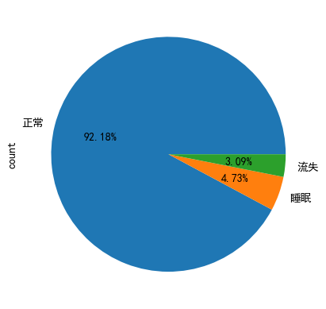

```python
# 得到每个用户最大活跃日期
AU_date=data.groupby('user_id')['date'].max().reset_index()
AU_date['几天没来']=(end_date-AU_date.date).dt.days
AU_date['用户状态']=np.where(AU_date['几天没来']>14,'流失'
                         ,np.where(AU_date['几天没来']>7,'睡眠','正常'))
AU_date
AU_date['用户状态'].value_counts().plot(kind='pie',
                                   autopct='%.2f%%')
```

项目名称：淘宝百万级用户行为分析

技术点：数据一致性处理+获客分析+留存分析+活跃分析+转化率

从公司数据库中取到用户行为数据，目标是深度分析用户行为，为运营 提供决策支持。

对数据进行描述性统计分析，构建业务指标，得到pv，uv，复购率等， 复购次数集中在1-5之间 2. 活跃分析：从时间维度分析用户行为，按天，按周，一天中不同时间段， 发现每周活跃时间集中在周二-周四，一天当中9:00-22:00，其中18:00-22:00 开始增加，达到一天中的顶峰，运营人员可根据活跃时间段安排相关活动 3. 获客分析：整体来看，每天都有新用户，但获客人数属于下降趋势， 后面需要设计活动进行拉新、 4. 留存分析：取日期最小值进行留存分析，次日留存率70%左右， 七日留存率65%，30日留存率60% 5. 转化率分析：总体转化率1%左右 6. 老用户状态进行分析，根据业务定义流失用户，睡眠用户，正常用户，得出结论，正常用户占92%，流失用户3%，睡眠用户5%左右，后续需要进行老用户促活，比如发起每日签到等任务。